# Farm Store Online Storefront Performance

Proposal Presentation: Analytics Objective 1

Danielle Meza

MSDM Culminating Experience Project, Cal Poly Pomona

2026-10-04

# Introduction

## Problem Statement

The CPP Farm Store sells produce, eggs, plants, and specialty products in the store and through an online store linked from cpp.com.<sup>1</sup>

- Inventory is tracked in **Clover**, but entry is largely **manual**, which is slow and error-prone.
- Manual entry contributes to **inventory shrink**, because mismatches between recorded and actual stock are hard to catch.
- The online store’s performance and visibility appear **underdeveloped**.
- The effectiveness of past promotions has **not been systematically measured**.
[^1]: Source: client meeting and Chapter 1 of the CEP proposal.

## Analytics Objective

> Generate insights from online store and Clover POS data to assess online storefront performance and identify friction points in the Clover-integrated purchase process.

**Supports PO1:** launch an online storefront and implement the best feasible Clover-Online store approach for payments, catalog, inventory, orders, and customer data.

### Data sources

- Clover POS reports
- Online store order data
- *(subject to access)*

### What we will examine

- Conversion rate
- Add-to-cart rate
- Share of revenue from online orders
- Clover vs. online catalog discrepancies

## Importance

The store has just launched an integrated storefront, so it needs **evidence** about whether the Clover connection works.

Findings will show **where the integration works and where friction** (such as sync delays or fulfillment issues) limits online sales.

That gives PO1 a data-backed basis for deciding **what to fix next**.

Chapter 1 of the CEP proposal describes how the four analytics objectives follow one customer journey.

# Literature Review

## Well-Established Models

Prior work on omnichannel retail gives a starting framework for AO1.

- Gallino and Moreno (2014) found that sharing inventory availability information changed customers’ purchasing behavior across channels. The **accuracy** of shared inventory data matters, not just its existence.
- Liu and Hassan (2024) link stronger omnichannel integration to better customer experience, satisfaction, and loyalty.
- Zhang et al. (2024) find that connectivity improves the **utilitarian** experience, meaning the trust that a listed product is really available.
- Thenoz et al. (2024) add a caution: e-commerce transformation succeeds or stalls based on **organizational and operational factors**, not storefront design alone.

## Adequateness of Information

### What would be sufficient

Clover transaction, catalog, and inventory data, combined with online store order data, would directly support the planned measures:

- conversion rate
- add-to-cart rate
- revenue share
- inventory-sync discrepancies

### What is still pending

**Pending:** Clover POS reporting access and online store platform permissions **have not been confirmed**.

. . .

Without access, the objective cannot move from planning to analysis.

## Need for Additional Analysis

Beyond the core transaction data, the objective would be stronger with:

- a record of **how often and how long** Clover inventory and the online catalog fall out of sync,
- any customer-facing **error or fulfillment logs**, and
- a defined **baseline period** before any Clover-online changes, so pre/post comparisons are possible.

**RQ1:** To what extent does the level of integration between Clover POS and the online storefront affect online conversion rate and the share of revenue captured online?

**H1:** Inventory/catalog discrepancies are associated with lower online conversion rates and a smaller share of revenue from the online channel.

# Methods

## Data and Sampling

- **Unit of analysis:** one week of storefront activity.
- **Planned sources:** Clover POS reports and online store orders, subject to access.
- **Sampling:** all available weeks in the study period, with a baseline period before any changes.

**Illustrative data**

Until Clover access is confirmed, the charts and tables in the next slides use **simulated data**. They show the planned analysis, not real Farm Store results.

```r
set.seed(6500)
weeks_raw <- tibble(
  week           = 1:12,
  sku_mismatches = rpois(12, lambda = 6),
  sessions       = round(rnorm(12, mean = 900, sd = 60)),
  conv_rate      = round(pmax(1.5, 4.2 - 0.15 * sku_mismatches +
                                rnorm(12, 0, 0.3)), 2)
)
```

## Data Wrangling

Planned steps: join Clover and online records by SKU, count weekly mismatches, then compute the measures. Here the same logic is applied to the simulated weeks.

```r
weeks <- weeks_raw |>
  mutate(
    orders = round(sessions * conv_rate / 100),
    sync_level = case_when(
      sku_mismatches <= 4 ~ "Low",
      sku_mismatches <= 8 ~ "Medium",
      TRUE                ~ "High"
    ),
    sync_level = factor(sync_level, levels = c("Low", "Medium", "High"))
  )

head(weeks, 5)
```

```
# A tibble: 5 × 6
   week sku_mismatches sessions conv_rate orders sync_level
  <int>          <int>    <dbl>     <dbl>  <dbl> <fct>
1     1              5      875      3.82     33 Medium
2     2              6      897      3.58     32 Medium
3     3              8      821      2.99     25 Medium
4     4              4      985      3.28     32 Low
5     5              8      870      3.15     27 Medium
```

## Sample Characteristics

The simulated sample has **12 weeks** and **343 online orders**. Illustrative

```r
weeks |>
  group_by(sync_level) |>
  summarise(
    weeks     = n(),
    sessions  = round(mean(sessions)),
    conv_rate = round(mean(conv_rate), 2)
  ) |>
  kable()
```

Table 1: Weekly averages by sync-mismatch level (simulated)

| sync_level | weeks | sessions | conv_rate |
| --- | --- | --- | --- |
| Low | 4 | 879 | 3.64 |
| Medium | 7 | 869 | 3.19 |
| High | 1 | 808 | 2.65 |

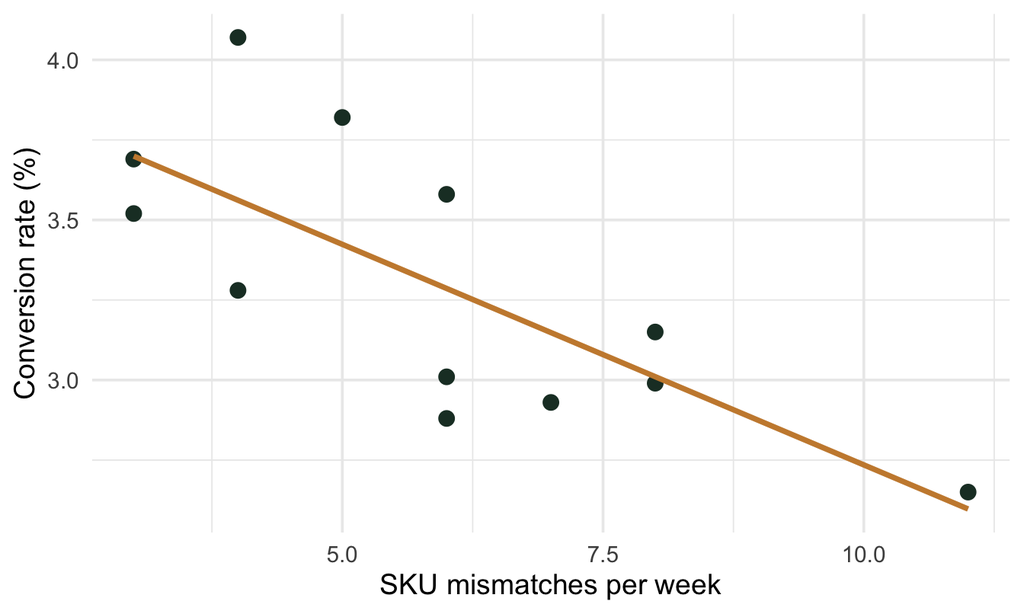

Figure 1: Conversion rate vs. weekly SKU mismatches (simulated)

```r
ggplot(weeks, aes(sku_mismatches, conv_rate)) +
  geom_point(size = 3, color = "#1F3A2E") +
  geom_smooth(method = "lm", se = FALSE, color = "#C98A3B") +
  labs(x = "SKU mismatches per week", y = "Conversion rate (%)") +
  theme_minimal(base_size = 14)
```

## Measures

| Measure | Definition |
| --- | --- |
| Conversion rate | Online orders ÷ store sessions |
| Add-to-cart rate | Sessions with an add-to-cart event ÷ sessions |
| Online revenue share | Online order revenue ÷ total revenue |
| Sync discrepancy | SKUs whose Clover quantity differs from online availability |

## Analytics Methods

1. **Descriptive statistics** of the four measures over time.
2. **Association check:** correlation and a simple regression of conversion rate on weekly mismatches (the test of H1).
3. **Pre/post comparison** against the baseline period once Clover-online changes are made.

```r
fit <- lm(conv_rate ~ sku_mismatches, data = weeks)
round(coef(summary(fit)), 3)
```

```
               Estimate Std. Error t value Pr(>|t|)
(Intercept)       4.113      0.247  16.672    0.000
sku_mismatches   -0.138      0.039  -3.536    0.005
```

The negative slope in this simulated example is what H1 predicts. Illustrative

# References

Gallino, Santiago, and Antonio Moreno. 2014. “Integration of Online and Offline Channels in Retail: The Impact of Sharing Reliable Inventory Availability Information.” *Management Science* 60 (6): 1434–51. https://doi.org/10.1287/mnsc.2014.1951.

Liu, Yuanyuan, and Siti Hasnah Hassan. 2024. “The Impact of Enhanced Omnichannel Integration on Consumer Responses in an Omnichannel Context.” *Global Business and Management Research* 16 (4s): 627–48.

Thenoz, Etienne, Solène Juteau, and Frantz Rowe. 2024. “E-Commerce Transformation: A Literature Review from an Institutional and Organizational Perspective.” *Electronic Markets* 34 (1): 59. https://doi.org/10.1007/s12525-024-00740-0.

Zhang, Xueting, Younggeun Park, Jaejin Park, and Hao Zhang. 2024. “Demonstrating the Influencing Factors and Outcomes of Customer Experience in Omnichannel Retail.” *Journal of Retailing and Consumer Services* 77 (March): 103622. https://doi.org/10.1016/j.jretconser.2023.103622.

# Appendix

## Links

- [Published slides](https://01a10a37-d710-1a1c-39c9-fa88411ef662.share.connect.posit.cloud/)
- [Gallino & Moreno (2014)](https://doi.org/10.1287/mnsc.2014.1951)
- [Zhang et al. (2024)](https://doi.org/10.1016/j.jretconser.2023.103622)
- [Thenoz et al. (2024)](https://doi.org/10.1007/s12525-024-00740-0)
- [Quarto Revealjs documentation](https://quarto.org/docs/presentations/revealjs/)